# Notes on GATS analysis

```r
library(here)
library(tidyverse)
library(haven)
library(modelsummary)
library(labelled)
library(gghighlight)
library(patchwork)
```

## 2023-11-08

The main purpose of this analysis is to generate estimates of dual and poly tobacco use across countries, and to look at associations with demographic (age, gender, education, wealth) and tobacco-specific (rules at home about tobacco use, knowledge about dangers of tobacco, etc.) covariates.

The main data source is the Global Adult Tobacco Surveys (GATS, from which years?), but some recoding is necessary because there are a number of issues with sparse cells, especially for some countries.

```r
gats <- read_sav(here("data-clean",
  "FOR MULTINOMIAL MULTILEVEL REGRESSION.sav"))
# add the SPSS labels
gats <- to_factor(gats)
datasummary_skim(gats)
```

Unique (#)

Missing (%)

Mean

SD

Min

Median

Max

ID

76913

0

389417.7

287618.6

1.0

401560.0

1001490.0

[figure not shown]

AGE

25952

0

42.8

17.1

15.0

40.1

116.0

[figure not shown]

knowscore

16

0

6.9

3.0

0.0

8.0

14.0

[figure not shown]

mpower

11

0

23.4

2.7

17.0

23.0

29.0

[figure not shown]

gatsstrata

351

0

1194.9

4745.7

1.0

41.0

29000.0

[figure not shown]

gatscluster

7366

0

200718391913.4

1125545406019.4

1.0

2011.0

9697232230011.0

[figure not shown]

gatsweight

133812

0

12896.7

25562.4

14.1

5437.6

1196008.6

[figure not shown]

Some empty cells by country with respect to education categories:

```r
gats %>% group_by(country_n, education) %>%
  tally() %>%
  spread(education, n)
```

| country_n | No education | Primary | Secondary | High school | College/University | <NA> |
| --- | --- | --- | --- | --- | --- | --- |
| 1. Uruguay | 158 | 1312 | 2061 | 309 | 1126 | NA |
| 2. China | 2333 | 5231 | 6010 | 3040 | 2762 | NA |
| 3. Indonesia | 1695 | 2476 | 1739 | 2411 | 835 | NA |
| 4. Kazakisthan | 39 | 659 | 5958 | 3943 | 78 | NA |
| 5. Vietnam | 396 | 3144 | 2528 | 1434 | 1485 | 9 |
| 6. Bangladesh | 3581 | 3630 | 3897 | 872 | 803 | NA |
| 7. Botswana | 583 | 840 | 1246 | 1069 | 905 | NA |
| 8. Costarica | 387 | 4029 | 1885 | 1325 | 981 | NA |
| 9. Ethiopia | 3787 | NA | 3453 | 617 | 1070 | 1223 |
| 10. Philippines | 1910 | 3430 | 1929 | 2694 | 1681 | NA |

[output cut: 8 more lines]

We have a similar problem for the wealth quintile variable, which appears to be based on the distribution across all countries. Here are the weighted quintiles for the entire sample:

```r
gats %>% group_by(wealthquintile) %>%
  summarise(n = sum(gatsweight)) %>%
  mutate(pct = n / sum(n) * 100)
```

| wealthquintile | n | pct |
| --- | --- | --- |
| First quintile | 653486033 | 21.84751 |
| Second | 547979195 | 18.32018 |
| Third | 593471513 | 19.84109 |
| Fourth | 597987865 | 19.99208 |
| Fifth | 598198598 | 19.99913 |

But looking by country, there are very different estimates across the quintiles, and in some cases countries with no observations in some quintiles.

```r
gats %>% group_by(country_n, wealthquintile) %>%
  tally() %>%
  spread(wealthquintile, n)
```

| country_n | First quintile | Second | Third | Fourth | Fifth |
| --- | --- | --- | --- | --- | --- |
| 1. Uruguay | 444 | 1543 | 1035 | 1202 | 742 |
| 2. China | 4170 | 2900 | 6076 | 2257 | 3973 |
| 3. Indonesia | 1643 | 1283 | 1563 | 1790 | 2877 |
| 4. Kazakisthan | 408 | 3354 | 1604 | 4208 | 1103 |
| 5. Vietnam | 2681 | 964 | 948 | 1409 | 2994 |
| 6. Bangladesh | 3968 | 1604 | 1189 | 2002 | 4020 |
| 7. Botswana | 1316 | 1223 | 95 | 415 | 1594 |
| 8. Costarica | NA | 2038 | 3338 | 2712 | 519 |
| 9. Ethiopia | 4385 | 1001 | 683 | 1869 | 2212 |
| 10. Philippines | 1778 | 1892 | 1596 | 3486 | 2892 |

[output cut: 8 more lines]

You can see there are no observations in the first quintile for Costa Rica or Turkey. So it also makes sense to categorize the wealth quintiles in to, say, 3 groups (1/2, 3, 4/5).

The `knowscore` variable is also rather unevenly distributed, even for the entire sample:

```r
gats %>% group_by(knowscore) %>%
  summarise(n = sum(gatsweight)) %>%
  mutate(pct = n / sum(n) * 100)
```

| knowscore | n | pct |
| --- | --- | --- |
| 0 | 159395925 | 5.3289656 |
| 1 | 137303790 | 4.5903756 |
| 2 | 324368044 | 10.8443558 |
| 3 | 240107428 | 8.0273333 |
| 4 | 331777874 | 11.0920832 |
| 5 | 366852507 | 12.2647073 |
| 6 | 134070303 | 4.4822728 |
| 7 | 214432789 | 7.1689721 |
| 8 | 377297756 | 12.6139156 |
| 9 | 554392192 | 18.5345823 |

[output cut: 6 more lines]

Collapsing these categories into a reasonable set of 3:

```r
gats %>%
  mutate(knows = ifelse(knowscore<=3, 1,
    ifelse(knowscore>3 & knowscore<8, 2,
      ifelse(knowscore>=8, 3, NA)))) %>%
  group_by(knows) %>%
  summarise(n = sum(gatsweight)) %>%
  mutate(pct = n / sum(n) * 100)
```

| knows | n | pct |
| --- | --- | --- |
| 1 | 861175188 | 28.7910303 |
| 2 | 1047133471 | 35.0080354 |
| 3 | 1073243874 | 35.8809651 |
| NA | 9570671 | 0.3199691 |

## 2023-11-16

Rationale for include interactions and varying effects. Although the raw dataset is quite large (>200k individual observations), it is still quite noisy when considering country-specific estimates by various combinations of demographic factors. For example, if we just group together both dual or poly tobacco use and want to assess how this may vary by gender and wealth, the country level estimates are quite noisy. Below shows the survey-weighted estimates of dual or poly use by country and wealth group, separately by gender.

```r
# read in the cleaned GATS data
gd <- read_rds(here("data-clean", "gats-clean.rds")) %>%
  select(-hwarn) %>%
  drop_na() %>%
  mutate(poly = ifelse(numtob > 1, 1, 0))

cinc <- gd %>%
  group_by(country, wealth, male) %>%
  summarise(tru_prev = weighted.mean(poly, weight) * 100)
```

```
can override using the `.groups` argument.
```

```r
m <- cinc %>%
  filter(male==1) %>%
  ggplot(aes(x=wealth, y=tru_prev,
             colour = country)) +
  geom_line() +
  scale_x_continuous(breaks = c(1,2,3)) +
  gghighlight(country %in%
    c("Bangladesh", "Senegal", "Romania")) +
  labs(x ='Wealth group',
       y ='Percentage of dual or poly-tobacco use' ) +
  ggtitle("Men") +
  theme_minimal()
```

```
label_key: country
```

```r
w <- cinc %>%
  filter(male==0) %>%
  ggplot(aes(x=wealth, y=tru_prev,
             colour = country)) +
  geom_line() +
  scale_x_continuous(breaks = c(1,2,3)) +
  gghighlight(country %in%
    # c("Romania", "Botswana", "Costa Rica")) +
      c("Bangladesh", "Senegal", "Romania")) +
  labs(x ='Wealth group',
       y ='Percentage of dual or poly-tobacco use' ) +
  ggtitle("Women") +
  theme_minimal()
```

```
label_key: country
```

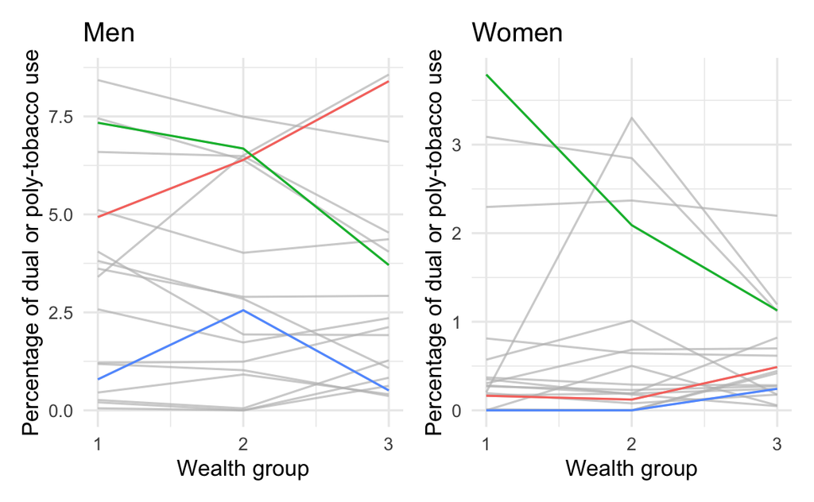

```r
m + w
```

## 2023-12-02

Experimented with the impact of allowing for outcome categories to be correlated within groups. Partly based on this bit from Andrew Heiss’s [blog](https://www.andrewheiss.com/blog/2023/08/12/conjoint-multilevel-multinomial-guide/#bayesian-model-with-brms):

> And also notice the slightly different syntax for the random respondent intercepts: (1 | ID | resp.id). That new middle ID is special {brms} formula syntax that we can use when working with categorical or ordinal families, and it makes it so that the group-level effects for the different outcomes (here options 0, 1, 2, and 3) are correlated (see p. 4 of this {brms} vignette for more about this special syntax).

Here is the model for setting the outcome categories within the multinomial outcome to be uncorrelated, but allowing for a random slope for wealth:

```r
m2 <-
  brm(numtob ~ 1 + (1 | wealth) +
        (1 + wealth | country),
    data = sample_data,
    family = categorical(link = "logit"),
    chains = 4, cores = 4, iter = 2000, seed = 1234)
```

Correlated outcomes but without a random slope for wealth:

```r
m3 <-
  brm(numtob ~ 1 + (1 | wealth) +
        (1 | ID | country),
    data = sample_data,
    family = categorical(link = "logit"),
    chains = 4, cores = 4, iter = 2000, seed = 1234)
```

And now allowing for correlated outcomes and random slopes for wealth:

```r
m4 <-
  brm(numtob ~ 1 + (1 | wealth) +
        (1 + wealth | ID | country),
    data = sample_data,
    family = categorical(link = "logit"),
    chains = 4, cores = 4, iter = 2000, seed = 1234)`
```

Results:

|  | M2 | M3 | M4 |
| --- | --- | --- | --- |
| b_mu1_Intercept | -1.471 | -1.420 | -1.463 |
|  | (0.233) | (0.380) | (0.241) |
| b_mu2_Intercept | -3.817 | -3.683 | -3.790 |
|  | (0.367) | (0.391) | (0.378) |
| b_mu3_Intercept | -8.190 | -7.848 | -8.163 |
|  | (1.830) | (1.355) | (1.869) |
| sd_country__mu1_Intercept | 0.665 | 0.620 | 0.617 |
|  | (0.223) | (0.125) | (0.197) |
| sd_country__mu1_wealth | 0.265 |  | 0.243 |
|  | (0.071) |  | (0.065) |
| sd_country__mu2_Intercept | 1.302 | 0.910 | 1.066 |
|  | (0.503) | (0.277) | (0.435) |
| sd_country__mu2_wealth | 0.582 |  | 0.472 |
|  | (0.195) |  | (0.160) |
| sd_country__mu3_Intercept | 1.297 | 0.952 | 1.222 |
|  | (1.185) | (0.810) | (1.029) |
| sd_country__mu3_wealth | 0.525 |  | 0.486 |
|  | (0.471) |  | (0.460) |
| cor_country__mu1_Intercept__mu1_wealth | -0.483 |  | -0.316 |
|  | (0.297) |  | (0.281) |
| cor_country__mu2_Intercept__mu2_wealth | -0.698 |  | -0.444 |
|  | (0.204) |  | (0.300) |
| cor_country__mu3_Intercept__mu3_wealth | -0.267 |  | -0.076 |
|  | (0.724) |  | (0.434) |
| cor_country__mu1_Intercept__mu2_Intercept |  | 0.719 | 0.323 |
|  |  | (0.188) | (0.311) |
| cor_country__mu1_Intercept__mu3_Intercept |  | 0.140 | 0.149 |
|  |  | (0.493) | (0.402) |
| cor_country__mu2_Intercept__mu3_Intercept |  | 0.030 | 0.164 |
|  |  | (0.487) | (0.399) |
| cor_country__mu1_wealth__mu2_Intercept |  |  | -0.002 |
|  |  |  | (0.322) |
| cor_country__mu1_Intercept__mu2_wealth |  |  | 0.011 |
|  |  |  | (0.328) |
| cor_country__mu1_wealth__mu2_wealth |  |  | 0.431 |
|  |  |  | (0.270) |
| cor_country__mu1_wealth__mu3_Intercept |  |  | -0.061 |
|  |  |  | (0.391) |
| cor_country__mu2_wealth__mu3_Intercept |  |  | -0.144 |
|  |  |  | (0.385) |
| cor_country__mu1_Intercept__mu3_wealth |  |  | 0.069 |
|  |  |  | (0.413) |
| cor_country__mu1_wealth__mu3_wealth |  |  | -0.045 |
|  |  |  | (0.399) |
| cor_country__mu2_Intercept__mu3_wealth |  |  | 0.044 |
|  |  |  | (0.417) |
| cor_country__mu2_wealth__mu3_wealth |  |  | -0.076 |
|  |  |  | (0.405) |
| sd_wealth__mu1_Intercept | 0.241 | 0.537 | 0.235 |
|  | (0.220) | (0.368) | (0.211) |
| sd_wealth__mu2_Intercept | 0.249 | 0.423 | 0.262 |
|  | (0.253) | (0.352) | (0.281) |
| sd_wealth__mu3_Intercept | 1.691 | 1.150 | 1.662 |
|  | (1.647) | (1.104) | (1.593) |
| Num.Obs. | 5000 | 5000 | 5000 |
| ELPD | -3176.4 | -3196.6 | -3177.1 |
| ELPD s.e. | 51.4 | 51.5 | 51.4 |
| LOOIC | 6352.8 | 6393.3 | 6354.3 |
| LOOIC s.e. | 102.8 | 103.0 | 102.8 |
| WAIC | 6351.8 | 6392.5 | 6353.2 |

You can see that allowing for correlated outcomes increases the number of estimated parameters, but this doesn’t seem to affect the overall estimated intercepts, so this may be inefficient. Let’s compare these 3 models using leave-one-out cross-validation:

Model comparisons using `loo`:

```r
> loo_compare(m2, m3, m4, criterion = "loo") %>% print(simplify = F)
   elpd_diff se_diff elpd_loo se_elpd_loo p_loo   se_p_loo looic   se_looic
m2     0.0       0.0 -3176.4     51.4        53.3     4.4   6352.8   102.8
m4    -0.7       1.7 -3177.1     51.4        50.2     4.1   6354.3   102.8
m3   -20.2       6.8 -3196.6     51.5        34.0     3.1   6393.3   103.0
```

Both models that allow for a random slope for wealth outperform the model without a random slope for wealth, and this is true for M4 even though it includes many additional parameters. However, on the whole it seems that allowing for correlated outcomes does not substantively or statistically improve the model.